# Pertemuan 5: Data Tidak Stasioner

Jonathan Marjono (G1401211064)

2023-09-28

# Data Penuh

## Library dan Packages

```r
library(ggplot2)
library(tsibble)
library(tseries)
library(MASS)
library(rio)
```

## Memasukkan Data

```r
dt.set <- import("https://raw.githubusercontent.com/jonathanmarjonoxz/MPDW/main/Responsi1/Data_ProduksiKaretKering.csv")
```

```r
View(dt.set) #Melihat data
str(dt.set) #Struktur data
```

```
## 'data.frame':    120 obs. of  2 variables:
##  $ Periode              : int  1 2 3 4 5 6 7 8 9 10 ...
##  $ Produksi Karet Kering: num  50 45.5 40.1 38.8 47.2 43.5 45.8 41.7 38.4 38.2 ...
```

```r
dim(dt.set) #Dimensi data
```

```
## [1] 120   2
```

## Plot Time Series

```r
#Mengubah agar terbaca sebagai data deret waktu
dt.set.ts <- ts(dt.set$`Produksi Karet Kering`)
```

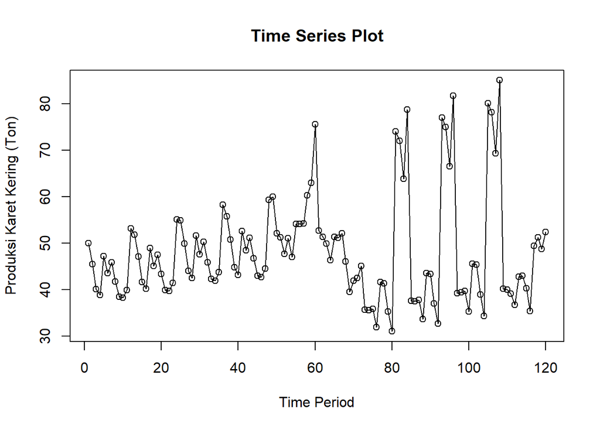

```r
#Cara 1
ts.plot(dt.set.ts, xlab="Time Period", ylab="Produksi Karet Kering (Ton)",
        main = "Time Series Plot")
points(dt.set.ts)
```

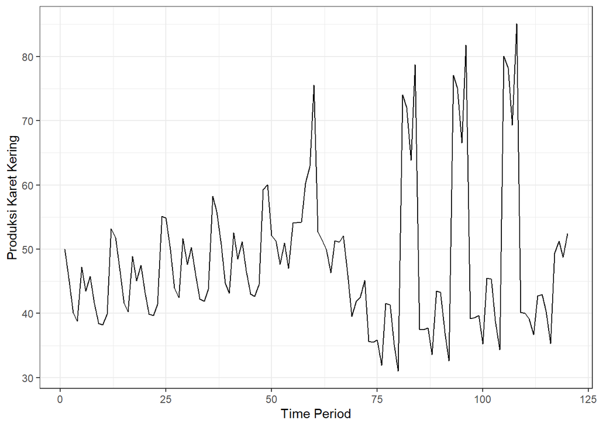

```r
#Cara 2
plot_stas <-dt.set.ts |> as_tsibble() |>
  ggplot(aes(x = index, y = value)) + geom_line() + theme_bw() +
  xlab("Time Period") + ylab("Produksi Karet Kering")
plot_stas
```

```r
summary(dt.set.ts) #Menampilkan ringkasan data
```

```
##    Min. 1st Qu.  Median    Mean 3rd Qu.    Max.
##   31.00   40.15   45.52   48.24   51.88   85.09
```

Plot deret waktu di atas terlihat menunjukkan stasioner dalam rataan, ditandai dengan data yang menyebar di sekitar nilai tengahnya (48.24), serta tidak stasioner dalam ragam sebab lebar pita yang cenderung berbeda. Namun untuk lebih pastinya dapat dibuat plot ACF, uji ADF, serta plot Box-Cox.

## Plot ACF

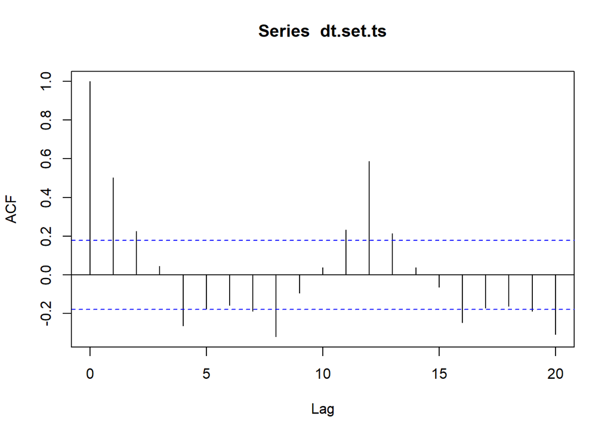

```r
acf(dt.set.ts)
```

Berdasarkan plot ACF di atas, terlihat bahwa plot ACF data tersebut cenderung *tails off* dan membentuk gelombang sinus.

## Uji ADF

$H_0$: Data tidak stasioner dalam rataan

$H_1$: Data stasioner dalam rataan

```r
tseries::adf.test(dt.set.ts)
```

```
##
##  Augmented Dickey-Fuller Test
##
## data:  dt.set.ts
## Dickey-Fuller = -4.8677, Lag order = 4, p-value = 0.01
## alternative hypothesis: stationary
```

Berdasarkan uji ADF, didapatkan *p-value* sebesar 0.01 yang lebih kecil dari taraf nyata 5% sehingga tolak $H_0$ dan menandakan bahwa data stasioner dalam rataan. Hal ini sesuai dengan hasil eksplorasi menggunakan plot time series serta plot ACF.

## Plot Boxcox

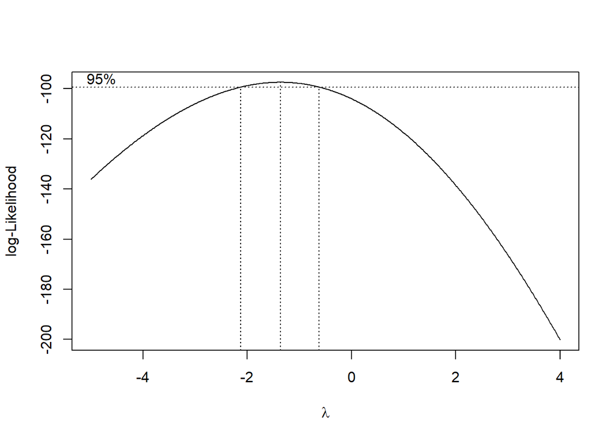

```r
index <- seq(1:120)
bc = boxcox(dt.set.ts~index, lambda = seq(-5,4,by=0.01))
```

```r
#Nilai rounded lambda
lambda <- bc$x[which.max(bc$y)]
lambda
```

```
## [1] -1.36
```

```r
#SK
bc$x[bc$y > max(bc$y) - 1/2 * qchisq(.95,1)]
```

```
##   [1] -2.12 -2.11 -2.10 -2.09 -2.08 -2.07 -2.06 -2.05 -2.04 -2.03 -2.02 -2.01
##  [13] -2.00 -1.99 -1.98 -1.97 -1.96 -1.95 -1.94 -1.93 -1.92 -1.91 -1.90 -1.89
##  [25] -1.88 -1.87 -1.86 -1.85 -1.84 -1.83 -1.82 -1.81 -1.80 -1.79 -1.78 -1.77
##  [37] -1.76 -1.75 -1.74 -1.73 -1.72 -1.71 -1.70 -1.69 -1.68 -1.67 -1.66 -1.65
##  [49] -1.64 -1.63 -1.62 -1.61 -1.60 -1.59 -1.58 -1.57 -1.56 -1.55 -1.54 -1.53
##  [61] -1.52 -1.51 -1.50 -1.49 -1.48 -1.47 -1.46 -1.45 -1.44 -1.43 -1.42 -1.41
##  [73] -1.40 -1.39 -1.38 -1.37 -1.36 -1.35 -1.34 -1.33 -1.32 -1.31 -1.30 -1.29
##  [85] -1.28 -1.27 -1.26 -1.25 -1.24 -1.23 -1.22 -1.21 -1.20 -1.19 -1.18 -1.17
##  [97] -1.16 -1.15 -1.14 -1.13 -1.12 -1.11 -1.10 -1.09 -1.08 -1.07 -1.06 -1.05
## [109] -1.04 -1.03 -1.02 -1.01 -1.00 -0.99 -0.98 -0.97 -0.96 -0.95 -0.94 -0.93
## [121] -0.92 -0.91 -0.90 -0.89 -0.88 -0.87 -0.86 -0.85 -0.84 -0.83 -0.82 -0.81
## [133] -0.80 -0.79 -0.78 -0.77 -0.76 -0.75 -0.74 -0.73 -0.72 -0.71 -0.70 -0.69
## [145] -0.68 -0.67 -0.66 -0.65 -0.64 -0.63
```

Gambar di atas menunjukkan nilai *rounded value* $(\lambda)$ optimum sebesar -1.36 dan pada selang kepercayaan 95% nilai memiliki batas bawah -2.12 dan batas atas -0.63. Selang tersebut tidak memuat nilai satu sehingga dapat dikatakan bahwa data produksi karet kering tersebut tidak stasioner dalam ragam.

# Partisi Data Bagian 1

## Mempartisi Data

```r
dt.set1 <- dt.set[1:25,-c(1)] |> ts()
mean(dt.set1)
```

```
## [1] 44.75
```

```r
var(dt.set1)
```

```
## [1] 27.64625
```

## Plot Time Series

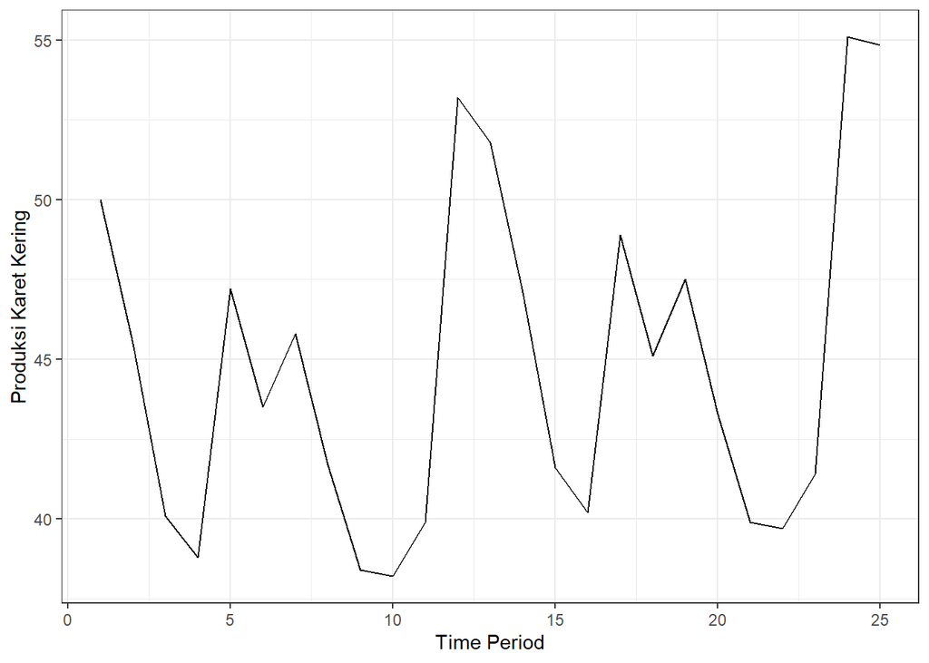

```r
dt.set1 |> as_tsibble() |>
  ggplot(aes(x = index, y = value)) +
  geom_line() + theme_bw() +
  xlab("Time Period") + ylab("Produksi Karet Kering")
```

Plot deret waktu di atas menunjukkan bahwa data stasioner dalam rataan, ditandai data menyebar disekitar nilai tengahnya (44.75) serta stasioner dalam ragam, ditandai dengan lebar pita yang cenderung sama.

## Plot ACF

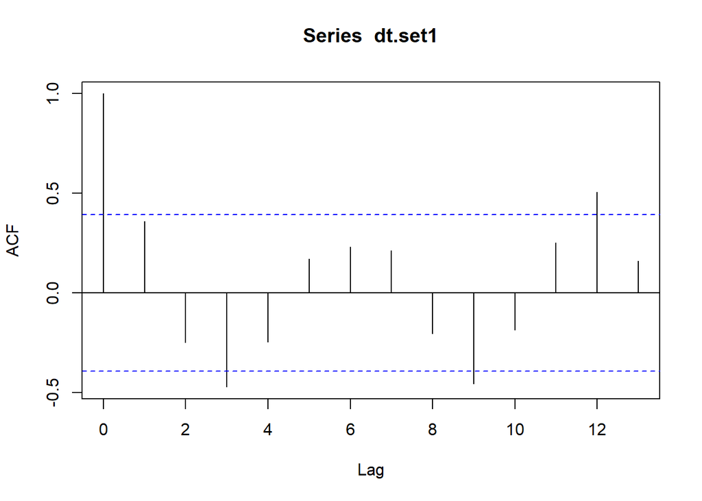

```r
acf(dt.set1)
```

Berdasarkan plot ACF di atas, terlihat bahwa plot ACF pada data tersebut cenderung *tails off* dan membentuk gelombang sinus.

## Uji ADF

$H_0$: Data tidak stasioner dalam rataan

$H_1$: Data stasioner dalam rataan

```r
tseries::adf.test(dt.set1)
```

```
##
##  Augmented Dickey-Fuller Test
##
## data:  dt.set1
## Dickey-Fuller = -4.4201, Lag order = 2, p-value = 0.01
## alternative hypothesis: stationary
```

Berdasarkan uji ADF tersebut, didapatkan nilai *p-value* sebesar 0.01 yang lebih kecil dari taraf nyata 5%, maka akan menolak $H_0$ sehingga menandakan bahwa data tersebut stasioner dalam rataan. Hal ini sesuai dengan hasil eksplorasi menggunakan plot time series dan plot ACF.

## Plot Boxcox

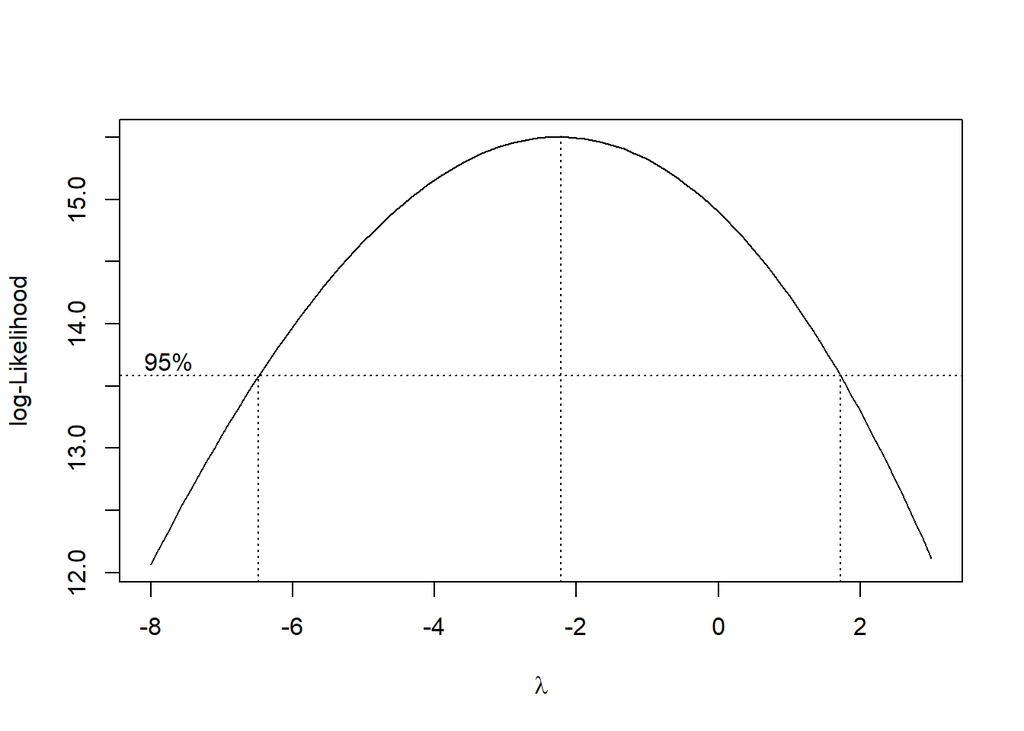

```r
index <- seq(1:25)
bc = boxcox(dt.set1~index, lambda = seq(-8,3,by=1))
```

```r
#Nilai Rounded Lambda
lambda <- bc$x[which.max(bc$y)]
lambda
```

```
## [1] -2.222222
```

```r
#SK
bc$x[bc$y > max(bc$y) - 1/2 * qchisq(.95,1)]
```

```
##  [1] -6.4444444 -6.3333333 -6.2222222 -6.1111111 -6.0000000 -5.8888889
##  [7] -5.7777778 -5.6666667 -5.5555556 -5.4444444 -5.3333333 -5.2222222
## [13] -5.1111111 -5.0000000 -4.8888889 -4.7777778 -4.6666667 -4.5555556
## [19] -4.4444444 -4.3333333 -4.2222222 -4.1111111 -4.0000000 -3.8888889
## [25] -3.7777778 -3.6666667 -3.5555556 -3.4444444 -3.3333333 -3.2222222
## [31] -3.1111111 -3.0000000 -2.8888889 -2.7777778 -2.6666667 -2.5555556
## [37] -2.4444444 -2.3333333 -2.2222222 -2.1111111 -2.0000000 -1.8888889
## [43] -1.7777778 -1.6666667 -1.5555556 -1.4444444 -1.3333333 -1.2222222
## [49] -1.1111111 -1.0000000 -0.8888889 -0.7777778 -0.6666667 -0.5555556
## [55] -0.4444444 -0.3333333 -0.2222222 -0.1111111  0.0000000  0.1111111
## [61]  0.2222222  0.3333333  0.4444444  0.5555556  0.6666667  0.7777778
## [67]  0.8888889  1.0000000  1.1111111  1.2222222  1.3333333  1.4444444
## [73]  1.5555556  1.6666667
```

Gambar di atas menunjukkan nilai *rounded value* $\lambda$ optimum sebesar -2.22 dan pada selang kepercayaan 95% nilai memiliki batas bawah -6.44 dan batas atas 1.67. Selang tersebut memuat nilai 1 sehingga dapat dikatakan bahwa data potongan bagian 1 tersebut stasioner dalam ragam.

# Partisi Data Bagian 2

## Mempartisi Data

```r
dt.set2 <- dt.set[1:100,-c(1)] |> ts()
mean(dt.set2)
```

```
## [1] 47.9311
```

```r
var(dt.set2)
```

```
## [1] 113.7733
```

## Plot Times Series

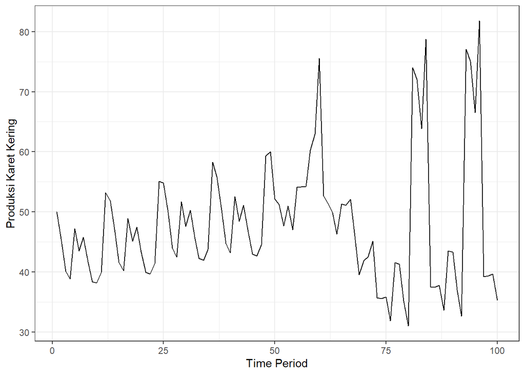

```r
dt.set2 |> as_tsibble() |>
  ggplot(aes(x = index, y = value)) +
  geom_line() + theme_bw() +
  xlab("Time Period") + ylab("Produksi Karet Kering")
```

Berdasarkan plot deret waktu di atas menunjukkan bahwa data stasioner dalam rataan, ditandai dengan data yang menyebar di sekitar nilai tengahnya (47.93), namun tidak stasioner dalam ragam, ditandai dengan lebar pita yang cenderung berbeda.

## Plot ACF

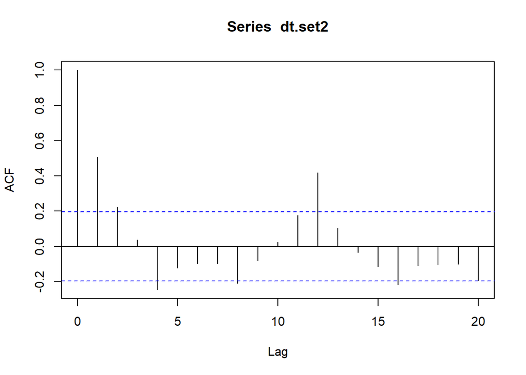

```r
acf(dt.set2)
```

Berdasarkan plot ACF, terlihat bahwa plot ACF pada data tersebut cenderung *tails off* dan membentuk gelombang sinus.

## Uji ADF

$H_0$: Data tidak stasioner dalam rataan

$H_1$: Data stasioner dalam rataan

```r
adf.test(dt.set2)
```

```
##
##  Augmented Dickey-Fuller Test
##
## data:  dt.set2
## Dickey-Fuller = -4.0551, Lag order = 4, p-value = 0.01
## alternative hypothesis: stationary
```

Berdasarkan uji ADF tersebut, didapatkan nilai *p-value* sebesar 0.01 yang lebih kecil dari taraf nyata 5%. Oleh karena itu tolak $H_0$ serta menandakan bahwa data tersebut stasioner dalam rataan. Hal ini sesuai dengan plot time series serta plot ACF.

## Plot Boxcox

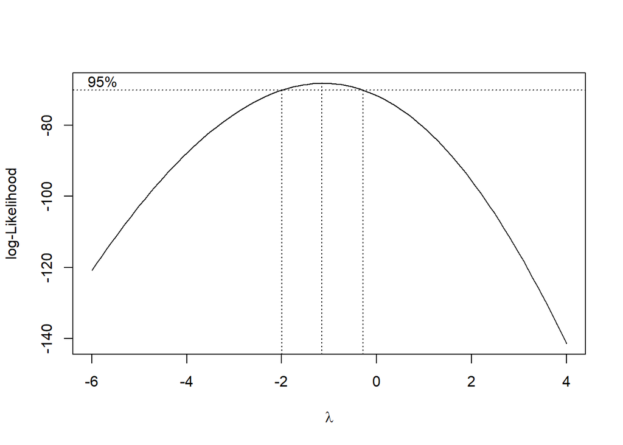

```r
index <- seq(1:100)
bc = boxcox(dt.set2~index, lambda = seq(-6,4,by=1))
```

```r
#Nilai Rounded Lambda
lambda <- bc$x[which.max(bc$y)]
lambda
```

```
## [1] -1.151515
```

```r
#SK
bc$x[bc$y > max(bc$y) - 1/2 * qchisq(.95,1)]
```

```
##  [1] -1.9595960 -1.8585859 -1.7575758 -1.6565657 -1.5555556 -1.4545455
##  [7] -1.3535354 -1.2525253 -1.1515152 -1.0505051 -0.9494949 -0.8484848
## [13] -0.7474747 -0.6464646 -0.5454545 -0.4444444 -0.3434343
```